# STAT 516 Lec 09

Randomized complete block designs

Karl Gregory

2026-10-26

# Nitrogen fertilization data from Kuehl (2000)

Six nitrogen timing schedules in each of four plots in a field of wheat. Response is the nitrate content in stem tissue samples.

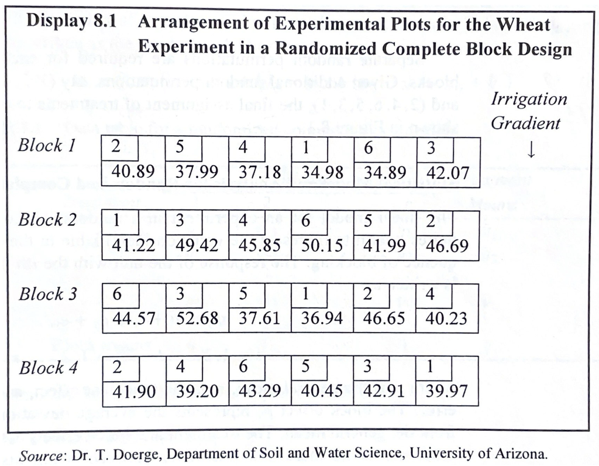

# Nitrogen fertilization

```r
ntr <- c(40.89,37.99,37.18,34.98,34.89,42.07,
         41.22,49.42,45.85,50.15,41.99,46.69,
         44.57,52.68,37.61,36.94,46.65,40.23,
         41.90,39.20,43.29,40.45,42.91,39.97)
block <- as.factor(c(1,1,1,1,1,1,2,2,2,2,2,2,3,3,3,3,3,3,4,4,4,4,4,4))
trt <- as.factor(c(2,5,4,1,6,3,1,3,4,6,5,2,6,3,5,1,2,4,2,4,6,5,3,1))
```

# Randomized complete block design (RCBD)

- EUs belong to blocks—groups of EUs homogeneous in some way.
- Each EU in a block is randomly assigned to a fixed treatment.
- All treatments appear exactly once in each block.
- Purpose is to capture the between-block variability among the EUs.
- This helps us detect treatment effects with greater power.

# Treatment effects model for the RCBD

Assume

$$Y_{ij} = \mu + \tau_i + B_j + \varepsilon_{ij}, \quad \text{ for } i=1,\dots,a, \quad j = 1,\dots,b,$$
where

- $Y_{ij}$ is the response of the EU in block $j$ receiving treatment $i$.
- the $\tau_i$ are the fixed effects of the treatment.
- the $B_j$ are independent $\mathcal{N}(0,\sigma_B^2)$ random block effects.
- the $\varepsilon_{ij}$ are independent $\mathcal{N}(0,\sigma_\varepsilon^2)$ error/interaction terms.
- $\mu$ is an overall or baseline mean.

Define the cell means as
$$\mu_i = \mu + \tau_i, \quad i = 1,\dots,a.$$

# Goals in the RCBD

In the randomized complete block design we wish to

1. Visualize the data.
2. Decompose the variability in the $Y_{ij}$ into its sources.
3. Estimate the variance components $\sigma_B^2$ and $\sigma_\varepsilon^2$.
4. Test whether the treatment has any effect.
5. Make comparisons between treatment means.
6. Check whether the model assumptions are satisfied.

# Nitrogen fertilization

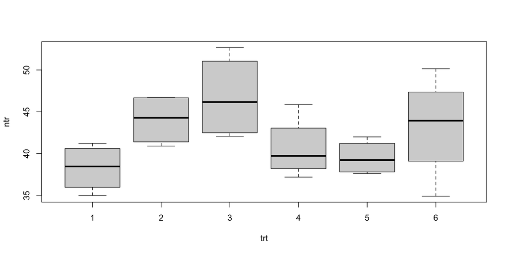

```r
boxplot(ntr~trt)
```

# Nitrogen fertilization

```r
stripchart(ntr~trt,vertical=T,method="jitter",xlab = "trt")
```

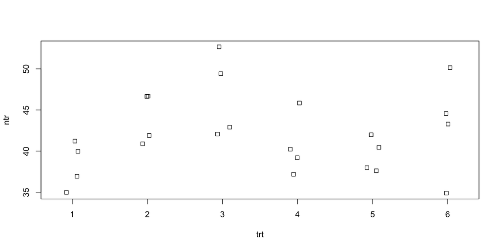

# Nitrogen fertilization

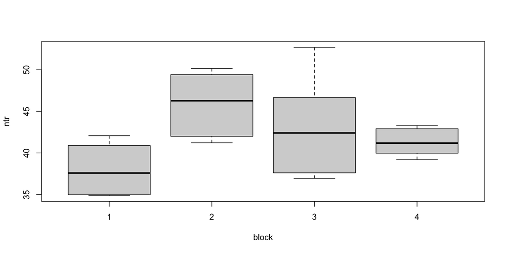

```r
boxplot(ntr~block)
```

# Nitrogen fertilization

```r
stripchart(ntr~block,vertical=T,method = "jitter",xlab = "block")
```

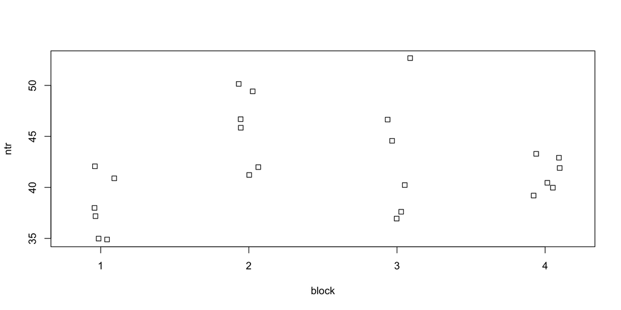

# Sums of squares for the RCBD

| Sum of squares | Symbol | Formula |
| --- | --- | --- |
| Total | $\operatorname{SS}_{\operatorname{Tot}}$ | $\sum_{i=1}^a\sum_{j=1}^b(Y_{ij} - \bar Y_{..})^2$ |
| Treatment | $\operatorname{SS}_{\operatorname{A}}$ | $b\sum_{i=1}^a (\bar Y_{i.} - \bar Y_{..})^2$ |
| Block | $\operatorname{SS}_{\operatorname{B}}$ | $a\sum_{j=1}^b (\bar Y_{.j} - \bar Y_{..})^2$ |
| Error | $\operatorname{SS}_{\operatorname{Error}}$ | $\sum_{i=1}^a \sum_{j=1}^b (Y_{ij} - (\bar Y_{i.} + \bar Y_{.j} - \bar Y_{..}))^2$ |

- We can make the decomposition $\operatorname{SS}_{\operatorname{Tot}}= \operatorname{SS}_{\operatorname{A}}+ \operatorname{SS}_{\operatorname{B}}+ \operatorname{SS}_{\operatorname{Error}}$.
- The $\operatorname{SS}_{\operatorname{Error}}$ is really the interaction sum of squares $\operatorname{SS}_{\operatorname{AB}}$.
- But without replication, we cannot estimate an interaction.
- So the interaction serves as the error term.

# ANOVA table for RCBD

| Source | Df | SS | MS | F value |
| --- | --- | --- | --- | --- |
| A | $a-1$ | $\operatorname{SS}_{\operatorname{A}}$ | $\operatorname{MS}_{\operatorname{A}}$ | $F_{\operatorname{A}} = \operatorname{MS}_{\operatorname{A}}/ \operatorname{MS}_{\operatorname{Error}}$ |
| B | $b-1$ | $\operatorname{SS}_{\operatorname{B}}$ | $\operatorname{MS}_{\operatorname{B}}$ | $F_{\operatorname{B}} = \operatorname{MS}_{\operatorname{B}}/ \operatorname{MS}_{\operatorname{Error}}$ |
| Error | $(a-1)(b-1)$ | $\operatorname{SS}_{\operatorname{Error}}$ | $\operatorname{MS}_{\operatorname{Error}}$ |  |
| Total | $ab-1$ | $\operatorname{SS}_{\operatorname{Tot}}$ |  |  |

1. Reject $H_0$: $\mu_1 = \dots = \mu_a$ if $F_{\operatorname{A}} > F_{a-1,(a-1)(b-1),\alpha}$.
2. Reject $H_0$: $\sigma_B^2 = 0$ if $F_{\operatorname{B}} > F_{b-1,(a-1)(b-1),\alpha}$.

# Nitrogen fertilization

Obtain ANOVA table “manually”:

```r
y <- ntr
y.. <- predict(lm(ntr ~ 1))
yi. <- predict(lm(ntr ~ trt))
y.j <- predict(lm(ntr ~ block))

SST <- sum((y - y..)^2)
SSA <- sum((yi. - y..)^2)
SSB <- sum((y.j - y..)^2)
SSE <- SST - (SSA + SSB)

a <- 6
b <- 4

MSA <- SSA/(a-1)
MSB <- SSB/(b-1)
MSE <- SSE/((a-1)*(b-1))

FA <- MSA / MSE
FB <- MSB / MSE

pA <- 1 - pf(FA,a-1,(a-1)*(b-1))
pB <- 1 - pf(FB,b-1,(a-1)*(b-1))
```

# Nitrogen fertilization

| Source | Df | SS | MS | F value | p value |
| --- | --- | --- | --- | --- | --- |
| A | 5 | 201.32 | 40.26 | 5.5917 | 0.0042 |
| B | 3 | 197.00 | 65.67 | 9.1198 | 0.0011 |
| Error | 15 | 108.01 | 7.20 |  |  |
| Total | 23 | 506.33 |  |  |  |

# Nitrogen fertilization

Obtain ANOVA table with `anova()` function on `lm()` output:

```r
lm_out <- lm(ntr ~ trt + block) # do not include the interaction
anova(lm_out)
```

```
Analysis of Variance Table

Response: ntr
          Df Sum Sq Mean Sq F value Pr(>F)
trt        5    201    40.3    5.59 0.0042 **
block      3    197    65.7    9.12 0.0011 **
Residuals 15    108     7.2
---
Signif. codes:  0 '***' 0.001 '**' 0.01 '*' 0.05 '.' 0.1 ' ' 1
```

# Expected mean squares in the RCBD

| Source | Df | Expected mean square |
| --- | --- | --- |
| A | $a-1$ | $b\theta_A^2 + \sigma^2_\varepsilon$ |
| B | $b-1$ | $a\sigma_B^2 + \sigma^2_\varepsilon$ |
| Error | $(a-1)(b-1)$ | $\sigma_\varepsilon^2$ |

In the above $\theta_A^2 = (a-1)^{-1}\sum_{i=1}^a(\mu_i - \bar\mu_.)^2$.

# Method of moments for variance components in RCBD

Equating $\operatorname{MS}_{\operatorname{B}}$ and $\operatorname{MS}_{\operatorname{Error}}$ with their expectations gives

- $\dot{\sigma}_{\varepsilon}^2 = \operatorname{MS}_{\operatorname{Error}}$.
- $\displaystyle \dot \sigma_B^2 = \frac{\operatorname{MS}_{\operatorname{B}}- \operatorname{MS}_{\operatorname{Error}}}{a}$

May obtain $\dot \sigma_B^2 < 0$, so one should use REML estimation.

# Nitrogen fertilization

Obtain REML estimators of $\sigma_B^2$ and $\sigma_{\varepsilon}^2$ on the fertilization data.

```r
library(lmerTest) # first time run install.packages("lmerTest")
lmer_out <- lmer(ntr ~ trt + (1|block))
lmer_out
```

```
Linear mixed model fit by REML ['lmerModLmerTest']
Formula: ntr ~ trt + (1 | block)
REML criterion at convergence: 102
Random effects:
 Groups   Name        Std.Dev.
 block    (Intercept) 3.12
 Residual             2.68
Number of obs: 24, groups:  block, 4
Fixed Effects:
(Intercept)         trt2         trt3         trt4         trt5         trt6
      38.28         5.75         8.49         2.34         1.23         4.95
```

# Nitrogen fertilization

Obtain MoMs estimators for $\sigma_B^2$ and $\sigma_{\varepsilon}^2$ on the fertilization data.

```r
sg_B <- sqrt((MSB - MSE)/a)
sg_e <- sqrt(MSE)
```

We have $\dot \sigma_B = 3.122$ and $\dot \sigma_{\varepsilon}= 2.683$.

# Variances of means and difference in means

[output not shown]

# Some (unadjusted) CIs in RCB split plot design

[output not shown]

In the above $\displaystyle \nu^* = \frac{\operatorname{MS}_{\operatorname{B}}+ (b-1)\operatorname{MS}_{\operatorname{Error}}}{\frac{\operatorname{MS}_{\operatorname{B}}^2}{(b-1)} + \frac{(b-1)^2\operatorname{MS}_{\operatorname{Error}}^2}{(a-1)(b-1)}}$ à la Satterthwaite.

# Nitrogen fertilization

Unadjusted CIs with `ls_means()` from R package `lmerTest`

```r
ls_means(lmer_out)
```

```
Least Squares Means table:

     Estimate Std. Error  df t value lower upper Pr(>|t|)
trt1    38.28       2.06 6.8    18.6 33.38 43.18  4.5e-07 ***
trt2    44.03       2.06 6.8    21.4 39.13 48.93  1.8e-07 ***
trt3    46.77       2.06 6.8    22.7 41.87 51.67  1.2e-07 ***
trt4    40.62       2.06 6.8    19.7 35.72 45.51  3.0e-07 ***
trt5    39.51       2.06 6.8    19.2 34.61 44.41  3.6e-07 ***
trt6    43.23       2.06 6.8    21.0 38.33 48.12  2.0e-07 ***
---
Signif. codes:  0 '***' 0.001 '**' 0.01 '*' 0.05 '.' 0.1 ' ' 1

  Confidence level: 95%
  Degrees of freedom method: Satterthwaite
```

# Nitrogen fertilization

```r
ls_means(lmer_out, pairwise = TRUE)
```

```
Least Squares Means table:

            Estimate Std. Error df t value   lower   upper Pr(>|t|)
trt1 - trt2   -5.755      1.897 15   -3.03  -9.799  -1.711  0.00839 **
trt1 - trt3   -8.492      1.897 15   -4.48 -12.537  -4.448  0.00044 ***
trt1 - trt4   -2.337      1.897 15   -1.23  -6.382   1.707  0.23694
trt1 - trt5   -1.232      1.897 15   -0.65  -5.277   2.812  0.52580
trt1 - trt6   -4.947      1.897 15   -2.61  -8.992  -0.903  0.01980 *
trt2 - trt3   -2.738      1.897 15   -1.44  -6.782   1.307  0.16965
trt2 - trt4    3.418      1.897 15    1.80  -0.627   7.462  0.09182 .
trt2 - trt5    4.522      1.897 15    2.38   0.478   8.567  0.03080 *
trt2 - trt6    0.808      1.897 15    0.43  -3.237   4.852  0.67646
trt3 - trt4    6.155      1.897 15    3.24   2.111  10.199  0.00545 **
trt3 - trt5    7.260      1.897 15    3.83   3.216  11.304  0.00165 **
trt3 - trt6    3.545      1.897 15    1.87  -0.499   7.589  0.08138 .
trt4 - trt5    1.105      1.897 15    0.58  -2.939   5.149  0.56897
trt4 - trt6   -2.610      1.897 15   -1.38  -6.654   1.434  0.18916
trt5 - trt6   -3.715      1.897 15   -1.96  -7.759   0.329  0.06911 .
---
Signif. codes:  0 '***' 0.001 '**' 0.01 '*' 0.05 '.' 0.1 ' ' 1

  Confidence level: 95%
  Degrees of freedom method: Satterthwaite
```

# Multiple comparisons in the RCBD

- Tukey’s for comparing all pairs of means among $\mu_1,\dots,\mu_a$:
  $$\bar Y_{i.} - \bar Y_{i'.} \pm q_{a,(a-1)(b-1),\alpha}\sqrt{\operatorname{MS}_{\operatorname{Error}}} \sqrt{\frac{1}{b}}, \quad 1 \leq i < i' \leq a.$$
- Dunnett’s for comparing $\mu_2,\dots,\mu_a$ to a baseline $\mu_1$:
  $$\bar Y_{i.} - \bar Y_{1.} \pm d_{a,(a-1)(b-1),\alpha}\sqrt{\operatorname{MS}_{\operatorname{Error}}}\sqrt{\frac{2}{b}}, \quad i=2,\dots,a.$$

# Nitrogen fertilization

Compare all pairs of fertilizers with Tukey’s CIs for mean differences.

```r
alpha <- 0.05
a <- 6
b <- 4
se <- sqrt(MSE) * sqrt(2/b) # have compute MSE previously
me <- qtukey(1-alpha,a,(a-1)*(b-1)) / sqrt(2) * se
ntr_means <- aggregate(ntr, by = list(trt), mean)$x

CIs <- matrix(NA,choose(a,2),2)
comp <- numeric(choose(a,2))

k <- 1
for(i in 1:(a-1))
  for(j in (i+1):a){ # double loop takes us through all pairs

    dij <- ntr_means[i] - ntr_means[j]
    CIs[k,] <- c(dij - me, dij + me)
    comp[k] <- paste(i,"-",j)
    k <- k + 1

  }

colnames(CIs) <- c("lower","upper")
rownames(CIs) <- comp
```

# Nitrogen fertilization

```r
round(CIs,3)
```

```
       lower upper
1 - 2 -11.92  0.41
1 - 3 -14.66 -2.33
1 - 4  -8.50  3.83
1 - 5  -7.40  4.93
1 - 6 -11.11  1.22
2 - 3  -8.90  3.43
2 - 4  -2.75  9.58
2 - 5  -1.64 10.69
2 - 6  -5.36  6.97
3 - 4  -0.01 12.32
3 - 5   1.09 13.43
3 - 6  -2.62  9.71
4 - 5  -5.06  7.27
4 - 6  -8.78  3.56
5 - 6  -9.88  2.45
```

# Nitrogen fertilization

Compare all fertilizers to fertilizer 1 using Dunnett’s method.

```r
alpha <- 0.05
a <- 6
b <- 4
me <- 2.82 * sqrt(MSE) * sqrt(2/b) # value 2.82 from Dunnett's table
ntr_means <- aggregate(ntr, by = list(trt), mean)$x

CIs <- matrix(NA,a-1,2)

k <- 1
for(i in 2:a){

  di <- ntr_means[i] - ntr_means[1]
  CIs[k,] <- c(di - me,di + me)
  k <- k + 1

}

colnames(CIs) <- c("lower","upper")
rownames(CIs) <- paste(2:a,"- 1")
```

# Nitrogen fertilization

```r
round(CIs,3)
```

```
       lower upper
2 - 1  0.404 11.11
3 - 1  3.142 13.84
4 - 1 -3.013  7.69
5 - 1 -4.118  6.58
6 - 1 -0.403 10.30
```

# Nitrogen fertilization

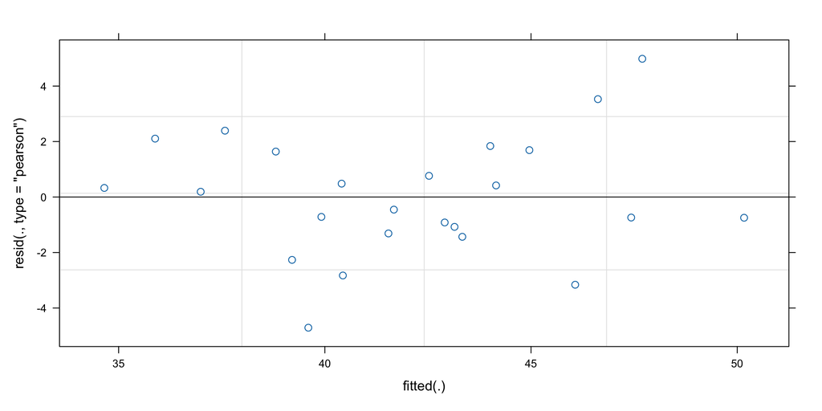

```r
plot(lmer_out)
```

# Nitrogen fertilization

```r
yhat <- predict(lmer_out)
ehat <- ntr - yhat
qqnorm(ehat)
```

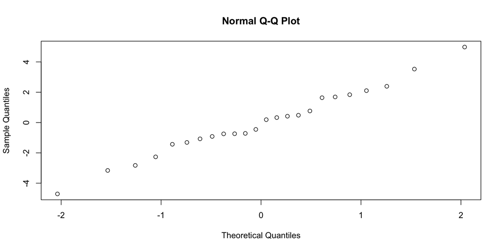

# Ignoring the blocks in the nitrogen data

If we ignore the blocks, the design looks like a one-way ANOVA:

[output not shown]

Suppose we fit $Y_{ij} = \mu + \tau_i + \varepsilon_{ij}$, $i = 1,2,3,4,5,6$, $j = 1,2,3,4$.

# Nitrogen fertilization

We lose power to detect a treatment effect!

```r
anova(lm(ntr ~ trt))
```

```
Analysis of Variance Table

Response: ntr
          Df Sum Sq Mean Sq F value Pr(>F)
trt        5    201    40.3    2.38   0.08 .
Residuals 18    305    16.9
---
Signif. codes:  0 '***' 0.001 '**' 0.01 '*' 0.05 '.' 0.1 ' ' 1
```

# Cabbage counts versus nitrogen, Kuehl (2000)

Heads of cabbage in subplots of two field plots.

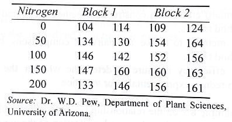

Subplots in each plot randomly assigned to nitrogen levels.

# Cabbage counts

```r
y <- c(104,114,109,124,
       134,130,154,164,
       146,142,152,156,
       147,160,160,163,
       133,146,156,161)

nitr <- as.factor(c(0,0,0,0,
                    50,50,50,50,
                    100,100,100,100,
                    150,150,150,150,
                    200,200,200,200))

blk <- as.factor(c(1,1,2,2,
                   1,1,2,2,
                   1,1,2,2,
                   1,1,2,2,
                   1,1,2,2))
```

# Cabbage counts

```r
ylims <- range(y)
par(bty = "l")
stripchart(y~nitr, subset=blk==1, vertical=TRUE, pch=19, ylim=ylims,xlab="nitr")
stripchart(y~nitr, subset=blk==2, vertical=TRUE, pch=1, add=TRUE)
legend("bottomright",legend = c("block 1", "block 2"),pch = c(19, 1),bty="n")
```

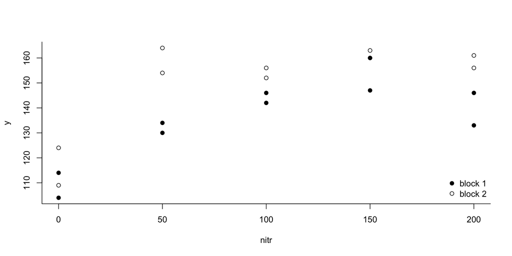

# Treatment effects model for RCBD with replication

Assume
$$Y_{ijk} + \mu + \tau_i + B_j + (\tau B)_{ij} + \varepsilon_{ijk}$$
for $i=1,\dots,a$, $j=1,\dots,b$, and $k = 1,\dots,n_{ij}$, where

- $Y_{ijk}$ is response of EU $k$ in block $j$ receiving treatment $i$.
- the $\tau_i$ are the fixed effects of the treatment.
- the $B_j$ are independent $\mathcal{N}(0,\sigma_B^2)$ random block effects.
- the $(\tau B)_{ij}$ are indep. $\mathcal{N}(0,\sigma_{AB}^2)$ random interaction effects.
- the $\varepsilon_{ijk}$ are independent $\mathcal{N}(0,\sigma_\varepsilon^2)$ error terms.
- $\mu$ is an overall or baseline mean.

Define the cell means as $\mu_i = \mu + \tau_i, \quad i = 1,\dots,a.$

Assume for now a balanced design: $n_{ij} = n$ for all $i,j$.

# Sums of squares for RCBD with replication

| Sum of squares | Symbol | Formula |
| --- | --- | --- |
| Total | $\operatorname{SS}_{\operatorname{Tot}}$ | $\sum_{i=1}^a\sum_{j=1}^b \sum_{k=1}^n (Y_{ijk} - \bar Y_{...})^2$ |
| Treatment | $\operatorname{SS}_{\operatorname{A}}$ | $nb\sum_{i=1}^a (\bar Y_{i..} - \bar Y_{...})^2$ |
| Block | $\operatorname{SS}_{\operatorname{B}}$ | $na\sum_{j=1}^b (\bar Y_{.j.} - \bar Y_{...})^2$ |
| Block $\times$ Treatment | $\operatorname{SS}_{\operatorname{AB}}$ | $n\sum_{i=1}^a \sum_{j=1}^b (\bar Y_{ij.} - (\bar Y_{i..} + \bar Y_{.j.} - \bar Y_{...}))^2$ |
| Error | $\operatorname{SS}_{\operatorname{Error}}$ | $\sum_{i=1}^a \sum_{j=1}^b \sum_{k=1}^n(Y_{ijk} - \bar Y_{ij.})^2$ |

- Can make the decomposition $\operatorname{SS}_{\operatorname{Tot}}= \operatorname{SS}_{\operatorname{A}}+ \operatorname{SS}_{\operatorname{B}}+ \operatorname{SS}_{\operatorname{AB}}+ \operatorname{SS}_{\operatorname{Error}}$.

# ANOVA table for RCBD with replication

| Source | Df | SS | MS | F value |
| --- | --- | --- | --- | --- |
| A | $a-1$ | $\operatorname{SS}_{\operatorname{A}}$ | $\operatorname{MS}_{\operatorname{A}}$ | $F_{\operatorname{A}} = \operatorname{MS}_{\operatorname{A}}/ \textcolor{red}{\operatorname{MS}_{\operatorname{AB}}}$ |
| B | $b-1$ | $\operatorname{SS}_{\operatorname{B}}$ | $\operatorname{MS}_{\operatorname{B}}$ | $F_{\operatorname{B}} = \operatorname{MS}_{\operatorname{B}}/ \textcolor{red}{\operatorname{MS}_{\operatorname{AB}}}$ |
| AB | $(a-1)(b-1)$ | $\operatorname{SS}_{\operatorname{AB}}$ | $\operatorname{MS}_{\operatorname{AB}}$ | $F_{\operatorname{AB}} = \operatorname{MS}_{\operatorname{AB}}/ \operatorname{MS}_{\operatorname{Error}}$ |
| Error | $ab(n-1)$ | $\operatorname{SS}_{\operatorname{Error}}$ | $\operatorname{MS}_{\operatorname{Error}}$ |  |
| Total | $abn-1$ | $\operatorname{SS}_{\operatorname{Tot}}$ |  |  |

1. Reject $H_0$: $\mu_1 = \dots = \mu_a$ if $F_{\operatorname{A}} > F_{a-1,\textcolor{red}{(a-1)(b-1)},\alpha}$.
2. Reject $H_0$: $\sigma_B^2 = 0$ if $F_{\operatorname{B}} > F_{b-1,\textcolor{red}{(a-1)(b-1)},\alpha}$.
3. Reject $H_0$: $\sigma_{AB}^2 = 0$ if $F_{\operatorname{AB}} > F_{(a-1)(b-1),ab(n-1),\alpha}$.

# Expected MS in RCBD with replication

| Source | Df | Expected mean square |
| --- | --- | --- |
| A | $a-1$ | $nb\theta_A^2 + n \sigma_{AB}^2 + \sigma^2_\varepsilon$ |
| B | $b-1$ | $na\sigma_B^2 + n \sigma_{AB}^2 + \sigma^2_\varepsilon$ |
| AB | $(a-1)(b-1)$ | $n \sigma_{AB}^2 + \sigma^2_\varepsilon$ |
| Error | $ab(n-1)$ | $\sigma_\varepsilon^2$ |

In the above $\theta_A^2 = (a-1)^{-1}\sum_{i=1}^a(\mu_i - \bar\mu_.)^2$.

Check expected MS values under each $H_0$ on previous slide.

# Cabbage counts

```r
a <- nlevels(nitr)
b <- nlevels(blk)
n <- 2

y... <- predict(lm(y ~ 1))
yi.. <- predict(lm(y ~ nitr))
y.j. <- predict(lm(y ~ blk))
yij. <- predict(lm(y ~ nitr + blk + nitr:blk))

SST <- sum((y - y...)**2)
SSA <- sum((yi.. - y...)**2)
SSB <- sum((y.j. - y...)**2)
SSAB <- sum((yij. - (yi.. + y.j. - y...))**2)
SSE <- sum((y - yij.)**2)

MSA <- SSA / (a-1)
MSB <- SSB / (b-1)
MSAB <- SSAB / ((a-1)*(b-1))
MSE <- SSE / (a*b*(n-1))

FA <- MSA / MSAB
FB <- MSB / MSAB
FAB <- MSAB / MSE

pA <- 1 - pf(FA,a-1,(a-1)*(b-1))
pB <- 1 - pf(FB,b-1,(a-1)*(b-1))
pAB <- 1 - pf(FAB,(a-1)*(b-1),a*b*(n-1))
```

# Cabbage counts

| Source | Df | SS | MS | F value | p value |
| --- | --- | --- | --- | --- | --- |
| A | 4 | 4813.00 | 1203.25 | 16.7234 | 0.0092 |
| B | 1 | 1022.45 | 1022.45 | 14.2106 | 0.0196 |
| AB | 4 | 287.80 | 71.95 | 1.7030 | 0.2253 |
| Error | 10 | 422.50 | 42.25 |  |  |
| Total | 19 | 6545.75 |  |  |  |

# Cabbage counts

Note that `anova()` on `lm()` output does not give desired output:

```r
anova(lm(y ~ nitr + blk + nitr:blk))
```

```
Analysis of Variance Table

Response: y
          Df Sum Sq Mean Sq F value  Pr(>F)
nitr       4   4813    1203    28.5 1.9e-05 ***
blk        1   1022    1022    24.2 0.00061 ***
nitr:blk   4    288      72     1.7 0.22531
Residuals 10    423      42
---
Signif. codes:  0 '***' 0.001 '**' 0.01 '*' 0.05 '.' 0.1 ' ' 1
```

# Method of moments for estimating $\sigma_B$, $\sigma_{AB}^2$, and $\sigma_\varepsilon^2$

Set the mean squares equal to their expectations and solve:
$$\begin{aligned}
\operatorname{MS}_{\operatorname{B}}&\overset{\text{set}}{=} na\sigma_B^2 + n \sigma_{AB}^2 + \sigma_\varepsilon^2\\
\operatorname{MS}_{\operatorname{AB}}&\overset{\text{set}}{=} n \sigma_{AB}^2 + \sigma_\varepsilon^2\\
\operatorname{MS}_{\operatorname{Error}}&\overset{\text{set}}{=} \sigma_\varepsilon^2
\end{aligned}$$
Solve for $\sigma_B^2$, $\sigma_{AB}^2$, and $\sigma_\varepsilon^2$:
$$\begin{aligned}
\dot \sigma_B^2 & =\frac{1}{na}(\operatorname{MS}_{\operatorname{B}}- \operatorname{MS}_{\operatorname{AB}})\\
\dot \sigma_{AB}^2 &=\frac{1}{n}(\operatorname{MS}_{\operatorname{AB}}- \operatorname{MS}_{\operatorname{Error}})\\
\dot \sigma_\varepsilon^2 &=\operatorname{MS}_{\operatorname{Error}}
\end{aligned}$$

Possible to obtain negative values for $\dot \sigma_B^2$ and $\dot \sigma_{AB}^2$. Then use REML.

# Cabbage counts

Obtain the method of moments estimates for the variance components.

```r
sigma_B_sq <- (MSB - MSAB) / (n*a)
sigma_AB_sq <- (MSAB - MSE) / n
sigma_e_sq <- MSE

sigma_B <- sqrt(sigma_B_sq)
sigma_AB <- sqrt(sigma_AB_sq)
sigma_e <- sqrt(sigma_e_sq)
```

We obtain $\dot \sigma_B = 9.749$, $\dot \sigma_{AB} = 3.854$, and $\dot \sigma_\varepsilon = 6.500$.

# Cabbage counts

Obtain the REML estimates for the variance components.

```r
library(lmerTest) # first time run install.packages("lmerTest")
lmer_out <- lmer(y ~ nitr + (1|blk) + (1|nitr:blk))
lmer_out
```

```
Linear mixed model fit by REML ['lmerModLmerTest']
Formula: y ~ nitr + (1 | blk) + (1 | nitr:blk)
REML criterion at convergence: 111
Random effects:
 Groups   Name        Std.Dev.
 nitr:blk (Intercept) 3.85
 blk      (Intercept) 9.75
 Residual             6.50
Number of obs: 20, groups:  nitr:blk, 10; blk, 2
Fixed Effects:
(Intercept)       nitr50      nitr100      nitr150      nitr200
      112.8         32.7         36.2         44.7         36.2
```

# CIs (unadjusted) for diffs in means in RCBD with rep.

- A $(1-\alpha)100\%$ confidence interval for $\mu_i - \mu_{i'}$ is
  $$\bar Y_{i..} - \bar Y_{i'..} \pm t_{(a-1)(b-1),\alpha/2}\sqrt{\operatorname{MS}_{\operatorname{AB}}}\sqrt{\frac{2}{nb}}$$
  for $1 \leq i < i' \leq a$.
- If $(a-1)(b-1) = 1$, this interval will be frightfully wide.
- In this case one should drop the interaction term from the model!

# CI for difference in means for cabbage count data

Compare the means of the nitrogen level $50$ and $0$ groups:

```r
y50.. <- mean(y[nitr == "50"])
y0.. <- mean(y[nitr == "0"])
alpha <- 0.05
tval <- qt(1 - alpha/2,(a-1)*(b-1))
me <- tval * sqrt(MSAB) * sqrt(2/(n*b))
lo <- y50.. - y0.. - me
up <- y50.. - y0.. + me
c(lo,up)
```

```
[1] 16.1 49.4
```

# CIs (unadjusted) for parameters in RCBD with replication

Use `confint()` on output of `lmer()`:

```r
confint(lmer_out)
```

```
            2.5 % 97.5 %
.sig01       0.00   6.25
.sig02       2.72  29.86
.sigma       4.42   9.06
(Intercept) 95.10 130.40
nitr50      23.25  42.25
nitr100     26.75  45.75
nitr150     35.25  54.25
nitr200     26.75  45.75
```

These CIs are *not* adjusted to achieve a familywise coverage probability!

# RCBD with replication *without* an interaction term

If we omit the interaction term in the RCBD with replication, we have

$$Y_{ijk} + \mu + \tau_i + B_j + \varepsilon_{ijk}$$
for $i=1,\dots,a$, $j=1,\dots,b$, and $k = 1,\dots,n_{ij}$, where

- $Y_{ijk}$ is response of EU $k$ in block $j$ receiving treatment $i$.
- the $\tau_i$ are the fixed effects of the treatment.
- the $B_j$ are independent $\mathcal{N}(0,\sigma_B^2)$ random block effects.
- the $\varepsilon_{ijk}$ are independent $\mathcal{N}(0,\sigma_\varepsilon^2)$ error terms.
- $\mu$ is an overall or baseline mean.

Assume for now a balanced design: $n_{ij} = n$ for all $i,j$.

Use this model if $a = b = 2$, under which $(a-1)(b-1)=1$.

# Sums of squares for RCBD with rep., no interaction

| SS | Symbol | Formula |
| --- | --- | --- |
| Total | $\operatorname{SS}_{\operatorname{Tot}}$ | $\sum_{i=1}^a\sum_{j=1}^b \sum_{k=1}^n (Y_{ijk} - \bar Y_{...})^2$ |
| Treatment | $\operatorname{SS}_{\operatorname{A}}$ | $nb\sum_{i=1}^a (\bar Y_{i..} - \bar Y_{...})^2$ |
| Block | $\operatorname{SS}_{\operatorname{B}}$ | $na\sum_{j=1}^b (\bar Y_{.j.} - \bar Y_{...})^2$ |
| Error | $\operatorname{SS}_{\operatorname{Error}}$ | $\sum_{i=1}^a \sum_{j=1}^b \sum_{k=1}^n(Y_{ijk} - (\bar Y_{i..} + \bar Y_{.j.} - \bar Y_{...}))^2$ |

- Can make the decomposition $\operatorname{SS}_{\operatorname{Tot}}= \operatorname{SS}_{\operatorname{A}}+ \operatorname{SS}_{\operatorname{B}}+ \operatorname{SS}_{\operatorname{Error}}$.

# ANOVA table for RCBD with rep., omitting interaction

| Source | Df | SS | MS | F value |
| --- | --- | --- | --- | --- |
| A | $a-1$ | $\operatorname{SS}_{\operatorname{A}}$ | $\operatorname{MS}_{\operatorname{A}}$ | $F_{\operatorname{A}} = \operatorname{MS}_{\operatorname{A}}/ \operatorname{MS}_{\operatorname{Error}}$ |
| B | $b-1$ | $\operatorname{SS}_{\operatorname{B}}$ | $\operatorname{MS}_{\operatorname{B}}$ | $F_{\operatorname{B}} = \operatorname{MS}_{\operatorname{B}}/ \operatorname{MS}_{\operatorname{Error}}$ |
| Error | $\textcolor{red}{abn-a - b + 1}$ | $\operatorname{SS}_{\operatorname{Error}}$ | $\operatorname{MS}_{\operatorname{Error}}$ |  |
| Total | $abn-1$ | $\operatorname{SS}_{\operatorname{Tot}}$ |  |  |

1. Reject $H_0$: $\mu_1 = \dots = \mu_a$ if $F_{\operatorname{A}} > F_{a-1,\textcolor{red}{abn-a - b + 1},\alpha}$.
2. Reject $H_0$: $\sigma_B^2 = 0$ if $F_{\operatorname{B}} > F_{b-1,\textcolor{red}{abn-a - b + 1},\alpha}$.

# Expected MS in RCBD with rep., omitting interaction

| Source | Df | Expected mean square |
| --- | --- | --- |
| A | $a-1$ | $nb\theta_A^2 + \sigma^2_\varepsilon$ |
| B | $b-1$ | $na\sigma_B^2 + \sigma^2_\varepsilon$ |
| Error | $abn - a - b + 1$ | $\sigma_\varepsilon^2$ |

In the above $\theta_A^2 = (a-1)^{-1}\sum_{i=1}^a(\mu_i - \bar\mu_.)^2$.

# Cabbage counts

ANOVA table, omitting the interaction:

```r
a <- nlevels(nitr)
b <- nlevels(blk)
n <- 2

y... <- predict(lm(y ~ 1))
yi.. <- predict(lm(y ~ nitr))
y.j. <- predict(lm(y ~ blk))

SST <- sum((y - y...)**2)
SSA <- sum((yi.. - y...)**2)
SSB <- sum((y.j. - y...)**2)
SSE <- sum((y - (yi.. + y.j. - y...))**2)

MSA <- SSA / (a-1)
MSB <- SSB / (b-1)
MSE <- SSE / (a*b*n - a - b + 1)

FA <- MSA / MSE
FB <- MSB / MSE

pA <- 1 - pf(FA,a-1,a*b*n - a - b + 1)
pB <- 1 - pf(FB,b-1,a*b*n - a - b + 1)
```

# Cabbage counts

| Source | Df | SS | MS | F value | p value |
| --- | --- | --- | --- | --- | --- |
| A | 4 | 4813.00 | 1203.25 | 23.7160 | 0.0000 |
| B | 1 | 1022.45 | 1022.45 | 20.1525 | 0.0005 |
| Error | 14 | 710.30 | 50.74 |  |  |
| Total | 19 | 6545.75 |  |  |  |

# Cabbage counts

With the interaction term omitting, `anova()` on `lm()` output is correct:

```r
anova(lm(y ~ nitr + blk))
```

```
Analysis of Variance Table

Response: y
          Df Sum Sq Mean Sq F value  Pr(>F)
nitr       4   4813    1203    23.7 4.1e-06 ***
blk        1   1022    1022    20.1 0.00051 ***
Residuals 14    710      51
---
Signif. codes:  0 '***' 0.001 '**' 0.01 '*' 0.05 '.' 0.1 ' ' 1
```

# MoM for variance components when omitting interaction

Set the mean squares equal to their expectations and solve:
$$\begin{aligned}
\operatorname{MS}_{\operatorname{B}}&\overset{\text{set}}{=} na\sigma_B^2 + \sigma_\varepsilon^2\\
\operatorname{MS}_{\operatorname{Error}}&\overset{\text{set}}{=} \sigma_\varepsilon^2
\end{aligned}$$
Solve for $\sigma_B^2$ and $\sigma_\varepsilon^2$:
$$\begin{aligned}
\dot \sigma_B^2 & =\frac{1}{na}(\operatorname{MS}_{\operatorname{B}}- \operatorname{MS}_{\operatorname{Error}})\\
\dot \sigma_\varepsilon^2 &=\operatorname{MS}_{\operatorname{Error}}
\end{aligned}$$

Possible to obtain a negative value for $\dot \sigma_B^2$. In this case use REML.

# Cabbage counts

MoM estimates when omitting interaction:

```r
sigma_B_sq <- (MSB - MSE) / (n*a)
sigma_e_sq <- MSE

sigma_B <- sqrt(sigma_B_sq)
sigma_e <- sqrt(sigma_e_sq)
```

We obtain $\dot \sigma_B = 9.858$ and $\dot \sigma_\varepsilon = 7.123$.

# Cabbage counts

REML estimates when omitting interaction:

```r
library(lmerTest) # first time run install.packages("lmerTest")
lmer_out <- lmer(y ~ nitr + (1|blk))
lmer_out
```

```
Linear mixed model fit by REML ['lmerModLmerTest']
Formula: y ~ nitr + (1 | blk)
REML criterion at convergence: 111
Random effects:
 Groups   Name        Std.Dev.
 blk      (Intercept) 9.86
 Residual             7.12
Number of obs: 20, groups:  blk, 2
Fixed Effects:
(Intercept)       nitr50      nitr100      nitr150      nitr200
      112.8         32.8         36.3         44.8         36.3
```

# CIs (unadjusted) for diffs in means in RCBD with rep. without interaction

- A $(1-\alpha)100\%$ confidence interval for $\mu_i - \mu_{i'}$ is
  $$\bar Y_{i..} - \bar Y_{i'..} \pm t_{abn - a - b + 1,\alpha/2}\sqrt{\operatorname{MS}_{\operatorname{Error}}}\sqrt{\frac{2}{nb}}$$
  for $1 \leq i < i' \leq a$.

# Cabbage counts

Compare the means of the nitrogen level $50$ and $0$ groups:

```r
y50.. <- mean(y[nitr == "50"])
y0.. <- mean(y[nitr == "0"])
alpha <- 0.05
tval <- qt(1 - alpha/2,a*b*n - a - b + 1)
me <- tval * sqrt(MSE) * sqrt(2/(n*b))
lo <- y50.. - y0.. - me
up <- y50.. - y0.. + me
c(lo,up)
```

```
[1] 21.9 43.6
```

# Cabbage counts

Can use `ls_means()` as below:

```r
ls_means(lmer_out,pairwise=T)
```

```
Least Squares Means table:

                  Estimate Std. Error df t value  lower  upper Pr(>|t|)
nitr0 - nitr50      -32.75       5.04 14   -6.50 -43.55 -21.95  1.4e-05 ***
nitr0 - nitr100     -36.25       5.04 14   -7.20 -47.05 -25.45  4.6e-06 ***
nitr0 - nitr150     -44.75       5.04 14   -8.88 -55.55 -33.95  4.0e-07 ***
nitr0 - nitr200     -36.25       5.04 14   -7.20 -47.05 -25.45  4.6e-06 ***
nitr50 - nitr100     -3.50       5.04 14   -0.69 -14.30   7.30    0.498
nitr50 - nitr150    -12.00       5.04 14   -2.38 -22.80  -1.20    0.032 *
nitr50 - nitr200     -3.50       5.04 14   -0.69 -14.30   7.30    0.498
nitr100 - nitr150    -8.50       5.04 14   -1.69 -19.30   2.30    0.114
nitr100 - nitr200     0.00       5.04 14    0.00 -10.80  10.80    1.000
nitr150 - nitr200     8.50       5.04 14    1.69  -2.30  19.30    0.114
---
Signif. codes:  0 '***' 0.001 '**' 0.01 '*' 0.05 '.' 0.1 ' ' 1

  Confidence level: 95%
  Degrees of freedom method: Satterthwaite
```

# Skin response data, Mohr, Wilson, and Freund (2021)

Galvanic skin responses of five subjects under shock and noise stimuli.

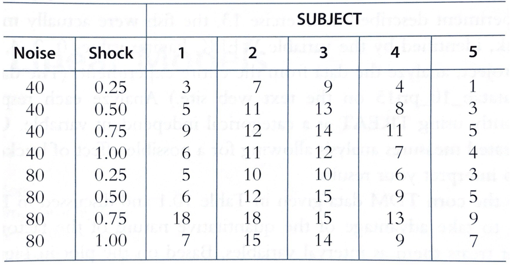

```r
skin <- data.frame(resp = c(3,7,9,4,1,5,11,13,8,3,9,12,14,11,5,6,11,12,7,4,5,
                            10,10,6,3,6,12,15,9,5,18,18,15,13,9,7,15,14,9,7),
                   noise = as.factor(c(rep(40,20),rep(80,20))),
                   shock = as.factor(rep(c(rep(.25,5),rep(.5,5),
                                           rep(.75,5),rep(1,5)),2)),
                   subj = as.factor(rep(1:5,8)))
```

# Skin response

```r
head(skin,n=20)
```

```
   resp noise shock subj
1     3    40  0.25    1
2     7    40  0.25    2
3     9    40  0.25    3
4     4    40  0.25    4
5     1    40  0.25    5
6     5    40   0.5    1
7    11    40   0.5    2
8    13    40   0.5    3
9     8    40   0.5    4
10    3    40   0.5    5
11    9    40  0.75    1
12   12    40  0.75    2
13   14    40  0.75    3
14   11    40  0.75    4
15    5    40  0.75    5
16    6    40     1    1
17   11    40     1    2
18   12    40     1    3
19    7    40     1    4
20    4    40     1    5
```

# Treatment effects model for two-way factorial RCBD

Assume
$$Y_{ijk} = \mu + \tau_i + \gamma_j + (\tau\gamma)_{ij} + C_k + \varepsilon_{ijk},$$
for $i = 1,\dots,a$, $j = 1,\dots,b$, and $k = 1,\dots,c$, where

- $Y_{ijk}$ is the response in block $k$ under treatment combination $i\times j$.
- $\mu$ is an overall or baseline mean.
- the $\tau_i$ are fixed effects for factor A.
- the $\gamma_j$ are fixed effects for factor B.
- the $(\tau\gamma)_{ij}$ are effects for the AB interaction.
- the $C_k$ are independent $\mathcal{N}(0,\sigma_C^2)$ block effects.
- the $\varepsilon_{ijk}$ are independent $\mathcal{N}(0,\sigma_\varepsilon^2)$ error terms.

Define the cell means as
$$\mu_{ij} = \mu + \tau_i + \gamma_j + (\tau\gamma)_{ij}, \quad i = 1,\dots,a, \quad j = 1,\dots,b.$$

# Sums of squares for the two-way factorial RCBD

| Sum of squares | Symbol | Formula |
| --- | --- | --- |
| Total | $\operatorname{SS}_{\operatorname{Tot}}$ | $\sum_{i=1}^a\sum_{j=1}^b\sum_{k=1}^c(Y_{ijk} - \bar Y_{...})^2$ |
| A | $\operatorname{SS}_{\operatorname{A}}$ | $bc\sum_{i=1}^a (\bar Y_{i..} - \bar Y_{...})^2$ |
| B | $\operatorname{SS}_{\operatorname{B}}$ | $ac\sum_{j=1}^b (\bar Y_{.j.} - \bar Y_{...})^2$ |
| AB | $\operatorname{SS}_{\operatorname{AB}}$ | $c\sum_{i=1}^a\sum_{j=1}^b (Y_{ij.} - (\bar Y_{i..} + \bar Y_{.j.} - \bar Y_{...}))^2$ |
| C | $\operatorname{SS}_{\operatorname{C}}$ | $ab\sum_{k=1}^c (\bar Y_{..k} - \bar Y_{...})^2$ |
| Error | $\operatorname{SS}_{\operatorname{Error}}$ | $\operatorname{SS}_{\operatorname{Tot}}- (\operatorname{SS}_{\operatorname{A}}+ \operatorname{SS}_{\operatorname{B}}+ \operatorname{SS}_{\operatorname{AB}}+ \operatorname{SS}_{\operatorname{C}})$ |

- Then we have $\operatorname{SS}_{\operatorname{Tot}}= \operatorname{SS}_{\operatorname{A}}+ \operatorname{SS}_{\operatorname{B}}+ \operatorname{SS}_{\operatorname{AB}}+ \operatorname{SS}_{\operatorname{C}}+ \operatorname{SS}_{\operatorname{Error}}$.
- The error $\operatorname{SS}_{\operatorname{Error}}$ is really the interaction sum of squares $\operatorname{SS}_{\operatorname{Trt}\times C}$.
- Again, without replication, we cannot estimate this interaction.
- So the interaction serves as the error term.

# ANOVA table for two-way factorial RCBD

[output not shown]

1. Reject $H_0$: $\mu_{1.} = \dots = \mu_{a.}$ if $F_{\operatorname{A}}> F_{a-1,(ab - 1)(c-1),\alpha}$.
2. Reject $H_0$: $\mu_{.1} = \dots = \mu_{.b}$ if $F_{\operatorname{B}}> F_{b-1,(ab - 1)(c-1),\alpha}$.
3. R. $H_0$: $\mu_{ij} = \bar \mu_{i.} + \bar \mu_{.j} - \bar \mu_{..}~ \forall ij$ if $F_{\operatorname{AB}}> F_{(a-1)(b-1),(ab - 1)(c-1),\alpha}$.
4. Reject $H_0$: $\sigma_C^2 = 0$ if $F_{\operatorname{C}}> F_{c-1,(ab - 1)(c-1),\alpha}$.

# Skin response

```r
lm_out <- lm(resp ~ noise + shock + noise:shock + subj, data = skin)
anova(lm_out)
```

```
Analysis of Variance Table

Response: resp
            Df Sum Sq Mean Sq F value  Pr(>F)
noise        1     65    65.0   28.38 1.1e-05 ***
shock        3    219    73.1   31.90 3.6e-09 ***
subj         4    362    90.5   39.48 4.0e-11 ***
noise:shock  3     13     4.2    1.84    0.16
Residuals   28     64     2.3
---
Signif. codes:  0 '***' 0.001 '**' 0.01 '*' 0.05 '.' 0.1 ' ' 1
```

# Skin response

```r
y <- skin$resp
y... <- predict(lm(resp ~ 1,data = skin))
yi.. <- predict(lm(resp ~ noise,data=skin))
y.j. <- predict(lm(resp ~ shock,data=skin))
y..k <- predict(lm(resp ~ subj,data=skin))
yij. <- predict(lm(resp ~ noise + shock + noise:shock,data=skin))

SSA <- sum((yi.. - y...)^2)
SSB <- sum((y.j. - y...)^2)
SSC <- sum((y..k - y...)^2)
SSAB <- sum((yij. - (yi.. + y.j. - y...))^2)
SST <- sum((y - y...)^2)
SSE <- SST - (SSA + SSB + SSC + SSAB)

a <- 2
b <- 4
c <- 5

MSA <- SSA/(a-1)
MSB <- SSB/(b-1)
MSC <- SSC/(c-1)
MSAB <- SSAB/((a-1)*(b-1))
MSE <- SSE/((a*b-1)*(c-1))

FA <- MSA / MSE
FB <- MSB / MSE
FAB <- MSAB / MSE
FC <- MSC / MSE

pA <- 1 - pf(FA,a-1,(a*b-1)*(c-1))
pB <- 1 - pf(FB,b-1,(a*b-1)*(c-1))
pAB <- 1 - pf(FAB,(a-1)*(b-1),(a*b-1)*(c-1))
pC <- 1 - pf(FC,c-1,(a*b-1)*(c-1))
```

# Skin response

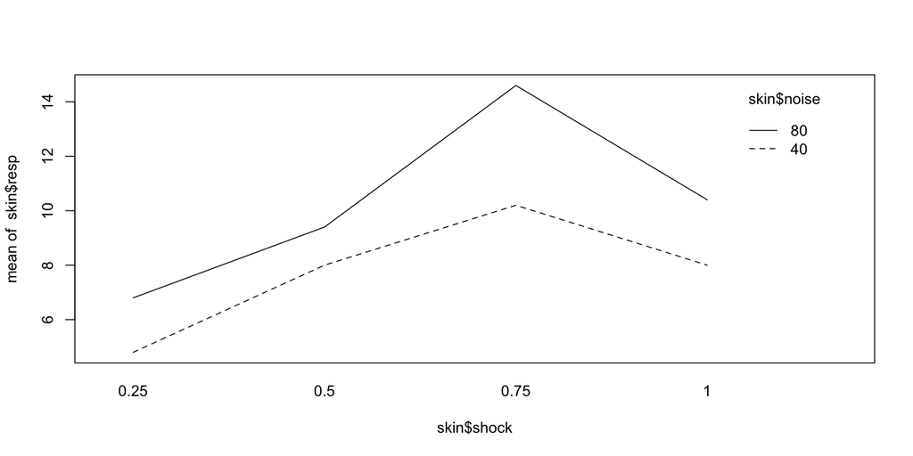

```r
interaction.plot(skin$shock,skin$noise,skin$resp)
```

# Expected mean squares in factorial RCBD

| Source | Df | Expected mean square |
| --- | --- | --- |
| A | $a-1$ | $bc \theta_A^2 + \sigma_\varepsilon^2$ |
| B | $b-1$ | $ac \theta_B^2 + \sigma_\varepsilon^2$ |
| AB | $(a-1)(b-1)$ | $c \theta_{AB}^2 + \sigma_\varepsilon^2$ |
| C | $c-1$ | $ab\sigma_C^2 + \sigma_\varepsilon^2$ |
| Error | $(ab-1)(c-1)$ | $\sigma_\varepsilon^2$ |

In the above

- $\theta_A^2 = (a-1)^{-1}\sum_{i=1}^a(\bar \mu_{i.} - \bar \mu_{..})^2$
- $\theta_B^2 = (b-1)^{-1}\sum_{j=1}^b(\bar \mu_{.j} - \bar \mu_{..})^2$
- $\theta_{AB}^2 = [(a-1)(b-1)]^{-1}\sum_{i=1}^a\sum_{j=1}^b(\mu_{ij} - (\bar \mu_{i.} + \bar \mu_{.j} - \bar \mu_{..}))^2$

# MoMs for variance components in two-way factorial RCBD

- Equating $\operatorname{MS}_{\operatorname{C}}$ and $\operatorname{MS}_{\operatorname{Error}}$ with their expectations gives

$$\dot \sigma_C^2 = \frac{\operatorname{MS}_{\operatorname{C}}- \operatorname{MS}_{\operatorname{Error}}}{ab} \quad \text{ and }\quad \displaystyle \dot \sigma_{\varepsilon}^2 = \operatorname{MS}_{\operatorname{Error}}.$$

- May obtain $\dot \sigma_C^2 < 0$, so one should use REML estimation.

# Skin response

Obtain REML estimators of $\sigma_C^2$ and $\sigma_{\varepsilon}^2$ on the skin response data.

```r
lmer_out <- lmer(resp ~ noise + shock + noise:shock + (1|subj), data = skin)
lmer_out
```

```
Linear mixed model fit by REML ['lmerModLmerTest']
Formula: resp ~ noise + shock + noise:shock + (1 | subj)
   Data: skin
REML criterion at convergence: 145
Random effects:
 Groups   Name        Std.Dev.
 subj     (Intercept) 3.32
 Residual             1.51
Number of obs: 40, groups:  subj, 5
Fixed Effects:
      (Intercept)            noise80           shock0.5          shock0.75
              4.8                2.0                3.2                5.4
           shock1   noise80:shock0.5  noise80:shock0.75     noise80:shock1
              3.2               -0.6                2.4                0.4
```

# Skin response

Obtain MoM estimates for $\sigma_C^2$ and $\sigma_{\varepsilon}^2$ on the skin response data.

```r
sg_C <- sqrt((MSC - MSE)/(a*b))
sg_e <- sqrt(MSE)
```

We have $\dot \sigma_C = 3.320$ and $\dot \sigma_{\varepsilon}= 1.514$.

# Skin response

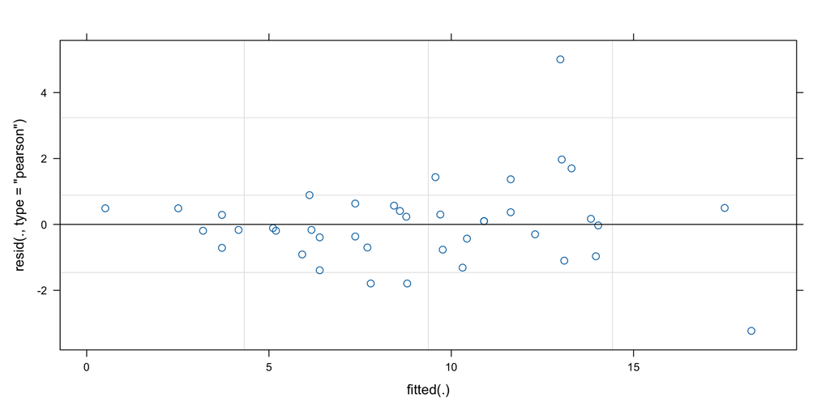

```r
plot(lmer_out)
```

# Skin response

```r
yhat <- predict(lmer_out)
ehat <- skin$resp - yhat
qqnorm(ehat)
```

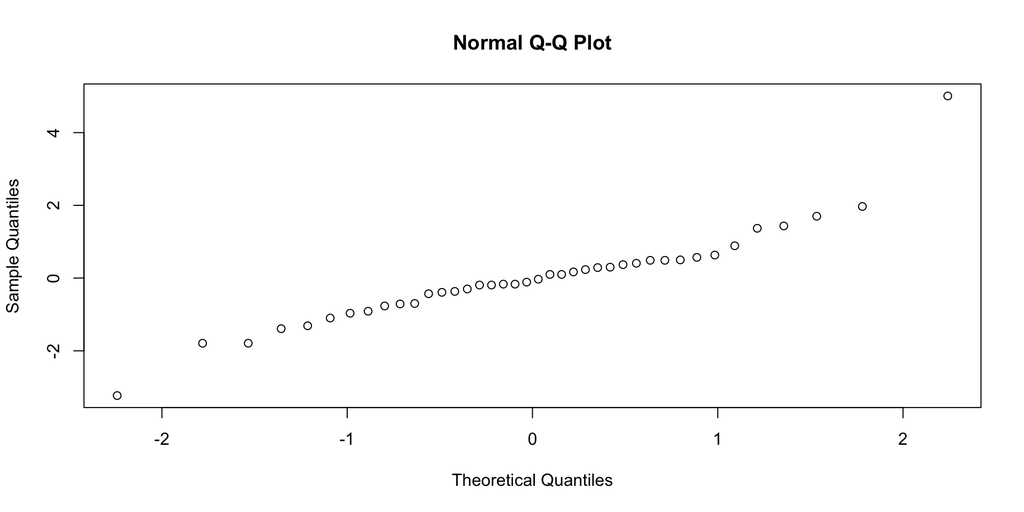

# References

Kuehl, R. O. 2000. *Design of Experiments: Statistical Principles of Research Design and Analysis*. Duxbury/Thomson Learning.

Mohr, Donna L, William J Wilson, and Rudolf J Freund. 2021. *Statistical Methods*. Academic Press.